# Final Project: Visual Motor Memory and its importance in handwriting and reading

Diana Sanchez

May 10, 2021

### Set-Up:

```r
library(tidyverse)
library(lme4)
library(knitr)
library(kableExtra)
library(patchwork)
library(dplyr)
library(lme4)
library(readr)
```

### Article Introduction

*The ontogeny of visual-motor memory and its importance in handwriting and reading: a developing construct*

Waterman, Havelka, Culmer, Hill, and Mon-Williams (2015) conducted a cross-sectional study to examine if working motor memory interacted with writing ability and reading skills. They shared their data as an open source.

### Dataset Loaded and Explored

The raw data available in csv format was loaded and explored.

```r
data_raw <- read_csv("data_raw/data_raw.csv")
View(data_raw)
summary(data_raw)
```

```
##       ID            YearGroup_School     Hand               Sex
##  Length:88          Min.   :2.000    Length:88          Length:88
##  Class :character   1st Qu.:2.000    Class :character   Class :character
##  Mode  :character   Median :4.000    Mode  :character   Mode  :character
##                     Mean   :3.886
##                     3rd Qu.:6.000
##                     Max.   :6.000
##  Date_of_test         Age_Cat          Reading_Level      Reading_converted
##  Length:88          Length:88          Length:88          Min.   : 1.000
##  Class :character   Class :character   Class :character   1st Qu.: 4.000
##  Mode  :character   Mode  :character   Mode  :character   Median : 7.000
##                                                           Mean   : 7.034
##                                                           3rd Qu.:10.000
##                                                           Max.   :14.000
##  Writing_Level      Writing_converted   Copying_OE       Shape1_OE
##  Length:88          Min.   : 1.000    Min.   : 1.417   Min.   :1.377
##  Class :character   1st Qu.: 3.000    1st Qu.: 2.346   1st Qu.:2.520
##  Mode  :character   Median : 6.000    Median : 3.377   Median :2.955
##                     Mean   : 5.682    Mean   : 3.648   Mean   :3.492
##                     3rd Qu.: 8.000    3rd Qu.: 4.300   3rd Qu.:4.269
##                     Max.   :10.000    Max.   :11.016   Max.   :8.643
##    Shape2_OE        Shape3_OE        Shape4_OE        Shape5_OE
##  Min.   : 1.606   Min.   : 2.231   Min.   : 1.926   Min.   : 2.213
##  1st Qu.: 3.533   1st Qu.: 3.408   1st Qu.: 3.580   1st Qu.: 3.820
##  Median : 4.858   Median : 4.348   Median : 4.742   Median : 4.889
##  Mean   : 5.489   Mean   : 5.156   Mean   : 5.279   Mean   : 5.491
##  3rd Qu.: 6.655   3rd Qu.: 6.014   3rd Qu.: 6.576   3rd Qu.: 6.228
##  Max.   :14.001   Max.   :15.418   Max.   :12.565   Max.   :18.029
##    Shape6_OE        Shape7_OE        Shape8_OE        Shape9_OE
##  Min.   : 2.673   Min.   : 1.521   Min.   : 1.977   Min.   : 2.070
##  1st Qu.: 3.954   1st Qu.: 3.892   1st Qu.: 4.142   1st Qu.: 3.750
##  Median : 5.311   Median : 5.411   Median : 5.390   Median : 5.385
##  Mean   : 6.155   Mean   : 5.654   Mean   : 5.603   Mean   : 5.860
##  3rd Qu.: 7.632   3rd Qu.: 6.898   3rd Qu.: 6.591   3rd Qu.: 6.633
##  Max.   :13.363   Max.   :14.353   Max.   :10.843   Max.   :18.560
##  OE_avg_simple   OE_avg_medium     OE_avg_hard     OE_avg_overall
##  Min.   :1.377   Min.   : 2.284   Min.   : 3.059   Min.   : 2.528
##  1st Qu.:2.520   1st Qu.: 4.117   1st Qu.: 4.418   1st Qu.: 4.101
##  Median :2.955   Median : 5.043   Median : 5.195   Median : 4.962
##  Mean   :3.492   Mean   : 5.395   Mean   : 5.777   Mean   : 5.353
##  3rd Qu.:4.269   3rd Qu.: 6.401   3rd Qu.: 6.557   3rd Qu.: 6.315
##  Max.   :8.643   Max.   :12.089   Max.   :12.422   Max.   :10.965
```

The first six rows of data_raw, provided by the authors is shown in the table below.

```r
head(data_raw) %>%
  kbl(caption = "First Six Rows of Raw Data") %>%
  kable_classic(full_width = F, html_font = "Cambria")
```

First Six Rows of Raw Data

| ID | YearGroup_School | Hand | Sex | Date_of_test | Age_Cat | Reading_Level | Reading_converted | Writing_Level | Writing_converted | Copying_OE | Shape1_OE | Shape2_OE | Shape3_OE | Shape4_OE | Shape5_OE | Shape6_OE | Shape7_OE | Shape8_OE | Shape9_OE | OE_avg_simple | OE_avg_medium | OE_avg_hard | OE_avg_overall |
| --- | --- | --- | --- | --- | --- | --- | --- | --- | --- | --- | --- | --- | --- | --- | --- | --- | --- | --- | --- | --- | --- | --- | --- |
| 1_3 | 2 | Right | F | 01/03/2012 | 6 to 7 | 2a | 3 | 2b | 3 | 6.345420 | 2.605968 | 5.381132 | 5.368010 | 6.543762 | 3.789973 | 6.756471 | 6.426706 | 9.288918 | 3.954527 | 2.605968 | 5.929902 | 5.947472 | 5.568385 |
| 1_4 | 2 | Right | M | 01/03/2012 | 6 to 7 | 2a | 3 | 2b | 3 | 5.345423 | 4.798491 | 7.226725 | 5.233565 | 5.788863 | 5.801190 | 7.596413 | 7.260190 | 9.009000 | 6.962847 | 4.798491 | 6.377336 | 7.342363 | 6.630809 |
| 1_5 | 2 | Right | M | 01/03/2012 | 6 to 7 | 3c | 4 | 3 | 6 | 4.224927 | 3.401520 | 5.431783 | 3.945177 | 5.982927 | 4.524844 | 10.014888 | 9.043090 | 6.868353 | 6.939202 | 3.401520 | 6.100744 | 7.086822 | 6.239087 |
| 1_6 | 2 | Right | F | 01/03/2012 | 6 to 7 | 3c | 4 | 3 | 6 | 4.787393 | 4.529510 | 4.953714 | 3.351611 | 6.065722 | 4.934225 | 4.485606 | 5.782128 | 5.947296 | 5.052574 | 4.529510 | 5.038294 | 5.104925 | 5.011376 |
| 1_8 | 2 | Right | M | 01/03/2012 | 6 to 7 | 2a | 3 | 3 | 6 | 3.400789 | 3.715510 | 6.684037 | 2.905206 | 5.004590 | 6.272246 | 5.819957 | 8.460163 | 6.240181 | 4.729986 | 3.715510 | 5.763499 | 5.765593 | 5.536875 |
| 1_9 | 2 | Right | M | 01/03/2012 | 6 to 7 | 2b | 2 | 2b | 3 | 4.715922 | 4.488269 | 9.865323 | 5.765470 | 9.088807 | 4.675680 | 10.686234 | 8.889006 | 6.954438 | 3.739492 | 4.488269 | 8.402151 | 6.513961 | 7.128080 |

### Tidy Data

Data was organized using pivot_longer(). Columns in the raw data set were separated by names and values.

```r
data_longer <- data_raw %>%
  pivot_longer(
    cols = Shape1_OE:Shape9_OE,
    names_to = "shape",
    values_to = "OE"
  ) %>%
  mutate(shape = factor(parse_number(shape))) %>%
  select(ID, YearGroup_School, Sex, Age_Cat, Reading_converted,
         Writing_converted, shape, OE)

head(data_longer) %>%
  kbl(caption = "Tidy Data with pivot_longer()") %>%
  kable_classic(full_width = F, html_font = "Cambria")
```

Tidy Data with pivot_longer()

| ID | YearGroup_School | Sex | Age_Cat | Reading_converted | Writing_converted | shape | OE |
| --- | --- | --- | --- | --- | --- | --- | --- |
| 1_3 | 2 | F | 6 to 7 | 3 | 3 | 1 | 2.605968 |
| 1_3 | 2 | F | 6 to 7 | 3 | 3 | 2 | 5.381132 |
| 1_3 | 2 | F | 6 to 7 | 3 | 3 | 3 | 5.368010 |
| 1_3 | 2 | F | 6 to 7 | 3 | 3 | 4 | 6.543762 |
| 1_3 | 2 | F | 6 to 7 | 3 | 3 | 5 | 3.789973 |
| 1_3 | 2 | F | 6 to 7 | 3 | 3 | 6 | 6.756471 |

Data was organized using select(). Specific Columns from raw data set were selected.

```r
data_tidy <- data_raw %>%
  select(ID, YearGroup_School, Sex, Age_Cat, Reading_converted,
         Writing_converted, OE_avg_simple, OE_avg_medium, OE_avg_hard,OE_avg_overall)

head(data_tidy) %>%
  kbl(caption = "Tidy Data with select()") %>%
  kable_classic(full_width = F, html_font = "Cambria")
```

Tidy Data with select()

| ID | YearGroup_School | Sex | Age_Cat | Reading_converted | Writing_converted | OE_avg_simple | OE_avg_medium | OE_avg_hard | OE_avg_overall |
| --- | --- | --- | --- | --- | --- | --- | --- | --- | --- |
| 1_3 | 2 | F | 6 to 7 | 3 | 3 | 2.605968 | 5.929902 | 5.947472 | 5.568385 |
| 1_4 | 2 | M | 6 to 7 | 3 | 3 | 4.798491 | 6.377336 | 7.342363 | 6.630809 |
| 1_5 | 2 | M | 6 to 7 | 4 | 6 | 3.401520 | 6.100744 | 7.086822 | 6.239087 |
| 1_6 | 2 | F | 6 to 7 | 4 | 6 | 4.529510 | 5.038294 | 5.104925 | 5.011376 |
| 1_8 | 2 | M | 6 to 7 | 3 | 6 | 3.715510 | 5.763499 | 5.765593 | 5.536875 |
| 1_9 | 2 | M | 6 to 7 | 2 | 3 | 4.488269 | 8.402151 | 6.513961 | 7.128080 |

### Plot the Data

#### Scatter Plots

Initial thought was to use a scatter plot to compare age and OE variables, however, age is not a continuous variable and boxplots appeared to be more appropriate. Below are examples of initial exploration plots.

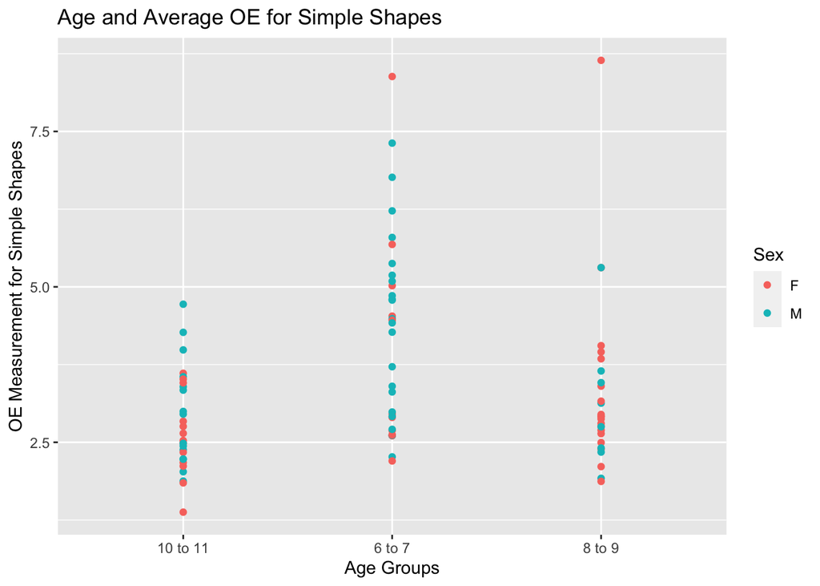

```r
  data_tidy %>%
  ggplot(aes(x = Age_Cat, y = OE_avg_simple, color = Sex)) +
  geom_point() +
  xlab("Age Groups") +
  ylab("OE Measurement for Simple Shapes") +
  ggtitle("Age and Average OE for Simple Shapes ")
```

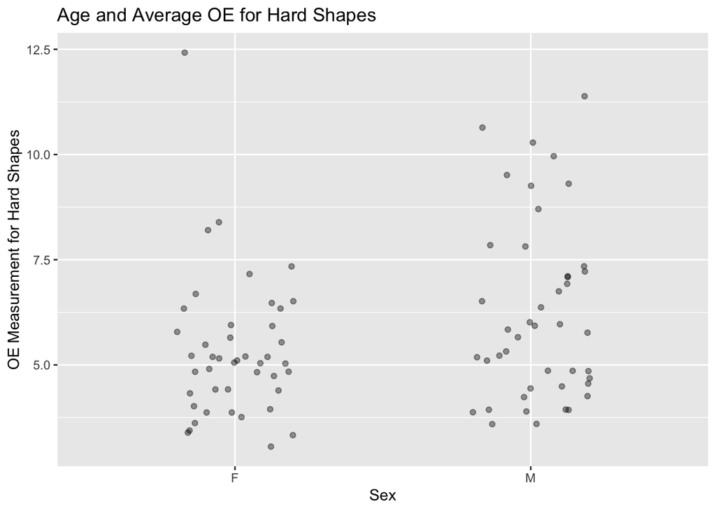

```r
data_tidy %>%
  ggplot(aes(x = Sex, y = OE_avg_hard)) +
  geom_jitter(alpha = 0.4, width = 0.2) +
  xlab("Sex") +
  ylab("OE Measurement for Hard Shapes") +
  ggtitle("Age and Average OE for Hard Shapes ")
```

#### Boxplots

In the boxplot below we can conclude that about 25% of our OE data has a value less than 3, our median value is about 4.5, and 75% of our data is less than 7. There are many data points (i.e., outliers) above 11 and that data has a positive skew.

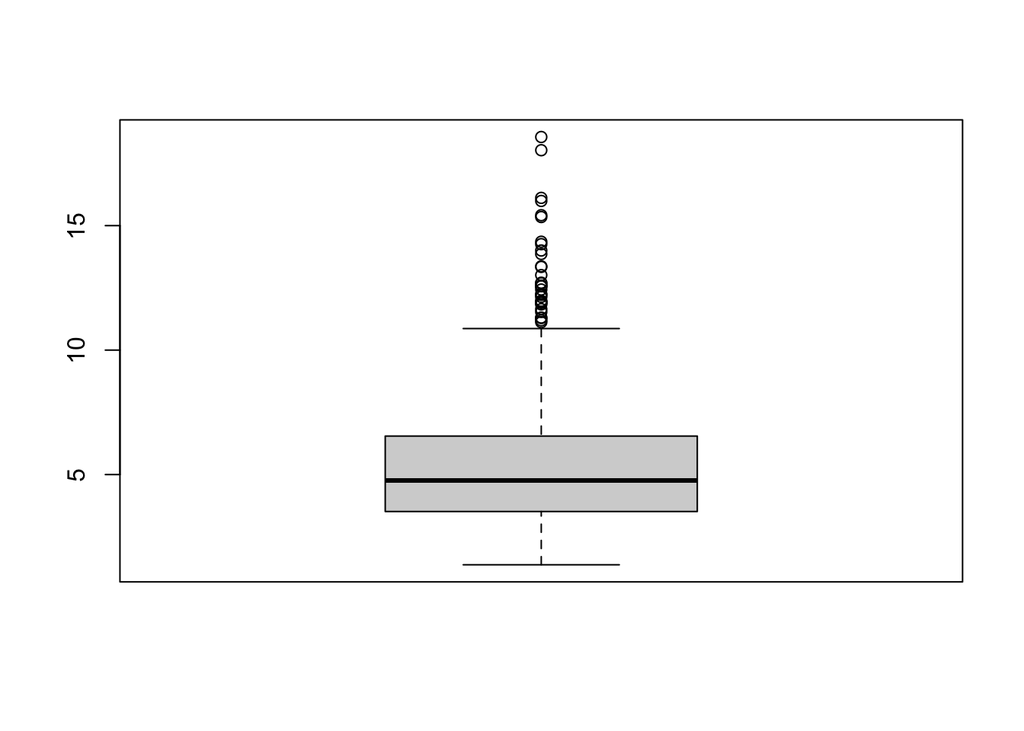

```r
boxplot(data_longer$OE)
```

Boxplots for age group and simple shapes.

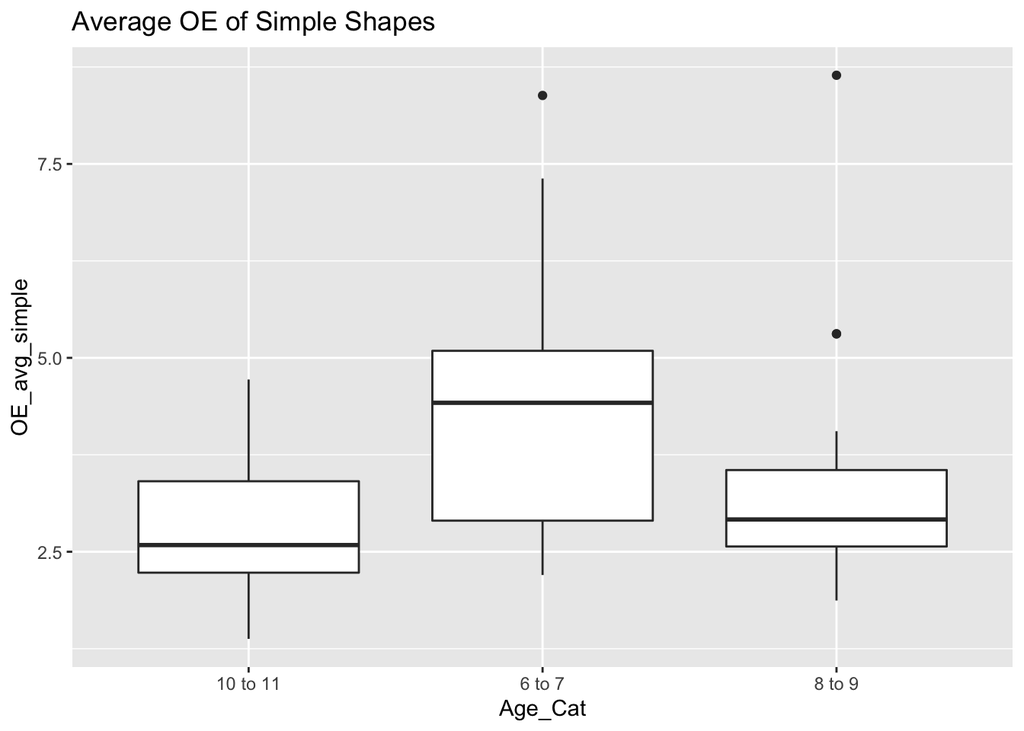

```r
data_tidy %>%
  ggplot(aes(x = Age_Cat, y = OE_avg_simple)) +
  geom_boxplot() +
  ggtitle("Average OE of Simple Shapes")
```

Boxplots for age group and medium shapes.

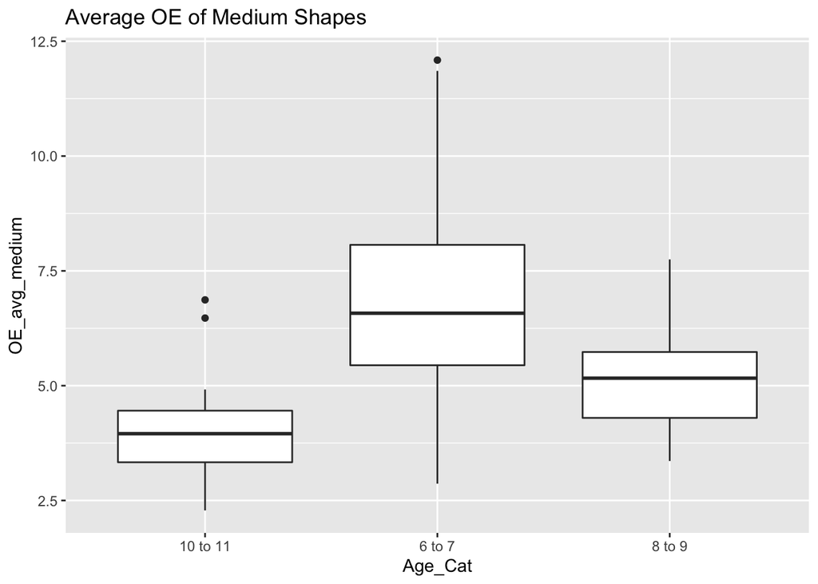

```r
data_tidy %>%
  ggplot(aes(x = Age_Cat, y = OE_avg_medium)) +
  geom_boxplot() +
  ggtitle("Average OE of Medium Shapes")
```

Boxplots for age group and hard shapes.

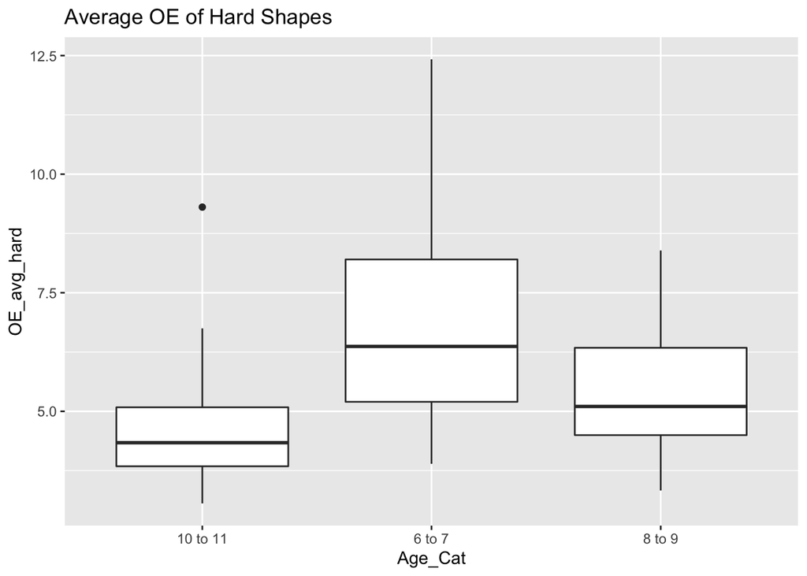

```r
data_tidy %>%
  ggplot(aes(x = Age_Cat, y = OE_avg_hard)) +
  geom_boxplot() +
  ggtitle("Average OE of Hard Shapes")
```

*Facet* analysis is used below to look at the relationship between different variables (i.e., sex and OE performance of the nine shapes).

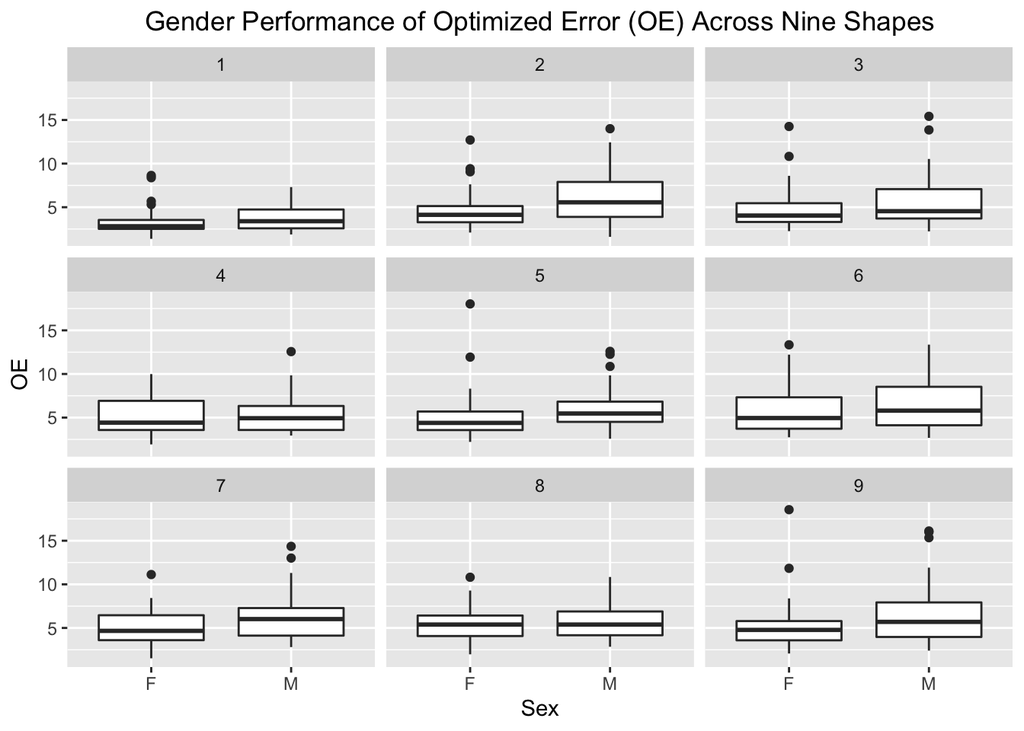

```r
data_longer %>%
  ggplot(aes(x = Sex, y = OE)) +
  geom_boxplot() +
  facet_wrap(vars(shape)) +
  ggtitle("Gender Performance of Optimized Error (OE) Across Nine Shapes") +
  theme(plot.title = element_text(hjust = 0.5))
```

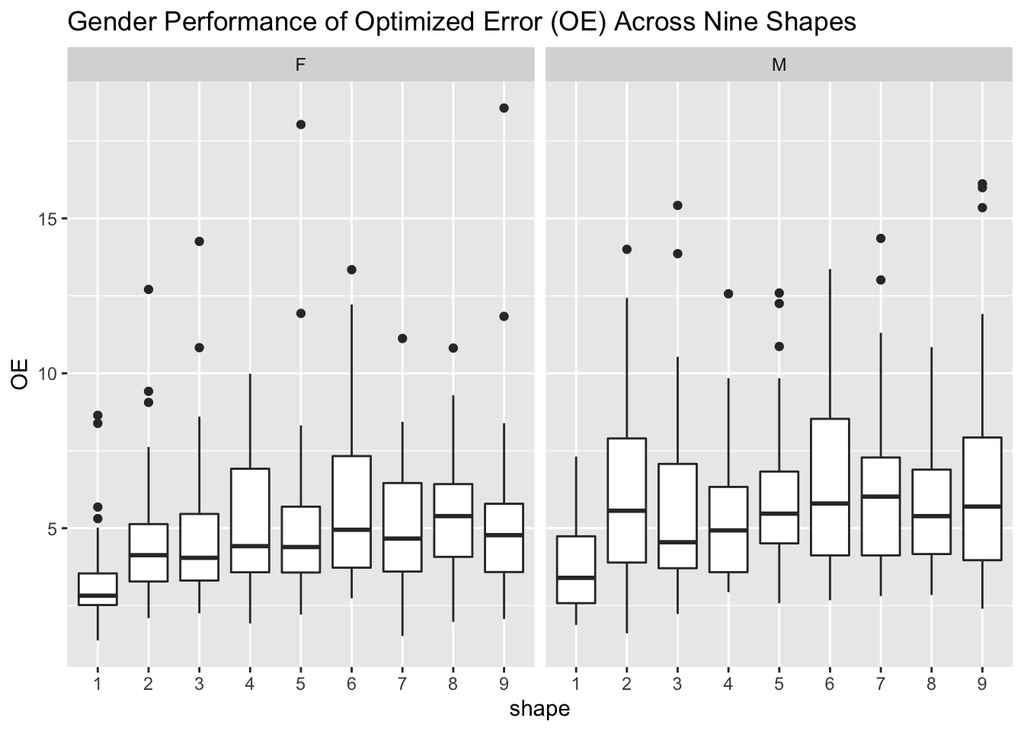

```r
data_longer %>%
  ggplot(aes(x = shape, y = OE)) +
  geom_boxplot() +
  facet_wrap(vars(Sex)) +
  ggtitle("Gender Performance of Optimized Error (OE) Across Nine Shapes")
```

### Data Description Analyses

```r
Gender_OE <- aov(OE~Sex + shape, data = data_longer)
```

```r
summary(Gender_OE)
```

```
##              Df Sum Sq Mean Sq F value   Pr(>F)
## Sex           1    156  155.83  26.256 3.77e-07 ***
## shape         8    405   50.59   8.523 3.63e-11 ***
## Residuals   782   4641    5.93
## ---
## Signif. codes:  0 '***' 0.001 '**' 0.01 '*' 0.05 '.' 0.1 ' ' 1
```

A Tukey’s HSD test was used after an ANOVA test to compare which groups’ means are different; essentially comparing all possible pairs of means.

```r
TukeyHSD(Gender_OE) #we need a post hoc test to compare groups
```

```
##   Tukey multiple comparisons of means
##     95% family-wise confidence level
##
## Fit: aov(formula = OE ~ Sex + shape, data = data_longer)
##
## $Sex
##          diff       lwr      upr p adj
## M-F 0.8871399 0.5472836 1.226996 4e-07
##
## $shape
##             diff        lwr       upr     p adj
## 2-1  1.996912824  0.8545368 3.1392889 0.0000026
## 3-1  1.664578142  0.5222021 2.8069542 0.0002315
## 4-1  1.787056324  0.6446803 2.9294324 0.0000483
## 5-1  1.999180330  0.8568043 3.1415564 0.0000025
## 6-1  2.663390182  1.5210141 3.8057663 0.0000000
## 7-1  2.161932847  1.0195568 3.3043089 0.0000002
## 8-1  2.111053886  0.9686778 3.2534300 0.0000005
## 9-1  2.367788051  1.2254120 3.5101641 0.0000000
## 3-2 -0.332334682 -1.4747108 0.8100414 0.9927009
## 4-2 -0.209856500 -1.3522326 0.9325196 0.9997276
## 5-2  0.002267506 -1.1401086 1.1446436 1.0000000
## 6-2  0.666477358 -0.4758987 1.8088534 0.6724472
## 7-2  0.165020023 -0.9773560 1.3073961 0.9999560
## 8-2  0.114141062 -1.0282350 1.2565171 0.9999975
## 9-2  0.370875227 -0.7715008 1.5132513 0.9849659
## 4-3  0.122478182 -1.0198979 1.2648543 0.9999956
## 5-3  0.334602187 -0.8077739 1.4769783 0.9923597
## 6-3  0.998812040 -0.1435640 2.1411881 0.1425568
## 7-3  0.497354705 -0.6450214 1.6397308 0.9142806
## 8-3  0.446475744 -0.6959003 1.5888518 0.9530674
## 9-3  0.703209909 -0.4391662 1.8455860 0.6036998
## 5-4  0.212124006 -0.9302521 1.3545001 0.9997048
## 6-4  0.876333858 -0.2660422 2.0187099 0.2929863
## 7-4  0.374876523 -0.7674995 1.5172526 0.9838937
## 8-4  0.323997562 -0.8183785 1.4663736 0.9938521
## 9-4  0.580731727 -0.5616443 1.7231078 0.8150124
## 6-5  0.664209852 -0.4781662 1.8065859 0.6765913
## 7-5  0.162752517 -0.9796236 1.3051286 0.9999604
## 8-5  0.111873557 -1.0305025 1.2542496 0.9999979
## 9-5  0.368607722 -0.7737683 1.5109838 0.9855485
## 7-6 -0.501457335 -1.6438334 0.6409187 0.9104462
## 8-6 -0.552336295 -1.6947124 0.5900398 0.8537879
## 9-6 -0.295602131 -1.4379782 0.8467739 0.9967307
## 8-7 -0.050878960 -1.1932550 1.0914971 1.0000000
## 9-7  0.205855205 -0.9365209 1.3482313 0.9997641
## 9-8  0.256734165 -0.8856419 1.3991102 0.9987994
```

#### Data Description Analysis for Sex (Female and Male)

Male and Female performance for the average score of the three-level (simple, medium, hard) shape complexity waere analyzed.

```r
data_description <- data_raw %>%
  group_by(Sex) %>%
   summarize(MeanOE_simple = mean(OE_avg_simple),
            sdOE_simple = sd(OE_avg_simple),
            MeanOE_medium = mean(OE_avg_medium),
            sdOE_medium = sd(OE_avg_medium),
            MeanOE_hard = mean(OE_avg_hard),
            sdOE_hard = sd(OE_avg_hard))

data_description %>%
 kbl(caption = "Gender Comparison of Optimized Error (OE) for Visual Motor Memory (VMM)") %>%
  kable_classic(full_width = F, html_font = "Cambria")
```

Gender Comparison of Optimized Error (OE) for Visual Motor Memory (VMM)

| Sex | MeanOE_simple | sdOE_simple | MeanOE_medium | sdOE_medium | MeanOE_hard | sdOE_hard |
| --- | --- | --- | --- | --- | --- | --- |
| F | 3.276097 | 1.471518 | 4.901004 | 1.444944 | 5.326671 | 1.656535 |
| M | 3.707688 | 1.359346 | 5.888021 | 2.136699 | 6.227820 | 2.114950 |

#### Data Description Analysis

A linear regression model was completed to fit models

```r
sex_OEhard<-lm(OE_avg_hard~Sex, data = data_tidy)
```

t-test used to determine significant difference between groups.

```r
t.test(OE_avg_hard~Sex, data = data_tidy)
```

```
##
##  Welch Two Sample t-test
##
## data:  OE_avg_hard by Sex
## t = -2.2251, df = 81.333, p-value = 0.02885
## alternative hypothesis: true difference in means is not equal to 0
## 95 percent confidence interval:
##  -1.70692353 -0.09537485
## sample estimates:
## mean in group F mean in group M
##        5.326671        6.227820
```

```r
summary(aov(sex_OEhard))
```

```
##             Df Sum Sq Mean Sq F value Pr(>F)
## Sex          1  17.87  17.866   4.951 0.0287 *
## Residuals   86 310.34   3.609
## ---
## Signif. codes:  0 '***' 0.001 '**' 0.01 '*' 0.05 '.' 0.1 ' ' 1
```

```r
summary(sex_OEhard)
```

```
##
## Call:
## lm(formula = OE_avg_hard ~ Sex, data = data_tidy)
##
## Residuals:
##     Min      1Q  Median      3Q     Max
## -2.6353 -1.3761 -0.2901  0.9080  7.0951
##
## Coefficients:
##             Estimate Std. Error t value Pr(>|t|)
## (Intercept)   5.3267     0.2864  18.600   <2e-16 ***
## SexM          0.9011     0.4050   2.225   0.0287 *
## ---
## Signif. codes:  0 '***' 0.001 '**' 0.01 '*' 0.05 '.' 0.1 ' ' 1
##
## Residual standard error: 1.9 on 86 degrees of freedom
## Multiple R-squared:  0.05443,    Adjusted R-squared:  0.04344
## F-statistic: 4.951 on 1 and 86 DF,  p-value: 0.02869
```

### Histogram Analysis

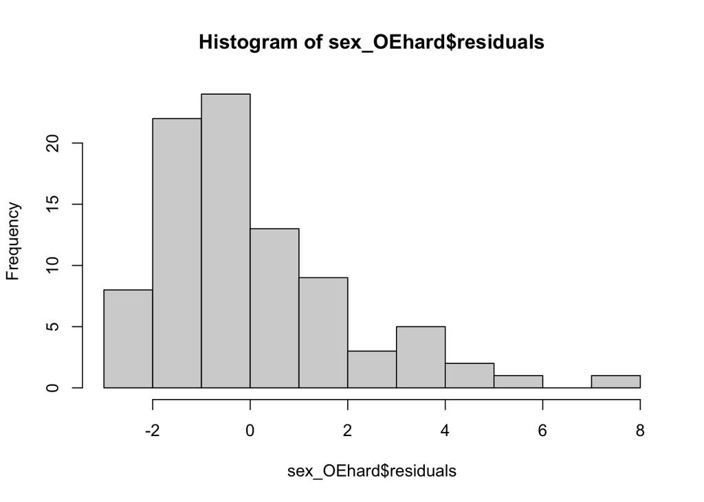

```r
hist(sex_OEhard$residuals)
```